# UNIT12A：邏輯式性回歸 Logistic Regression

中山大學管理學院 第21組

2019-05-20 10:53:40

```r
#　      ∧_∧:: <br>
#　　　 (´･ω･`):: <br>
#　　 /⌒　　⌒)::  <br>
#　　/ へ_＿/ /::  <br>
#　 (＿＼＼ﾐ)/::  <br>
#　　 ｜ `-イ::  <br>
#　　 /ｙ　 )::  <br>
#　　/／　／:: <br>
#　 ／　／:: <br>
#　(　く::: <br>
#　|＼ ヽ:::<br>
```

```r
pacman::p_load(ggplot2, dplyr)
```

### 【A】簡單案例

- 資料：Binary Target Variable

```r
D = read.csv("data/quality.csv")  # Read in dataset
D = D[,c(14, 4, 5)]
names(D) = c("y", "x1", "x2")
table(D$y)
```

```
 0  1
98 33
```

- 方法：`glm(, family=binomial)` Generalize Liner Model

```r
glm1 = glm(y~x1+x2, D, family=binomial)
summary(glm1)
```

```
Call:
glm(formula = y ~ x1 + x2, family = binomial, data = D)

Deviance Residuals:
   Min      1Q  Median      3Q     Max
-2.377  -0.627  -0.510  -0.154   2.119

Coefficients:
            Estimate Std. Error z value    Pr(>|z|)
(Intercept)  -2.5402     0.4500   -5.64 0.000000017 ***
x1            0.0627     0.0240    2.62     0.00892 **
x2            0.1099     0.0326    3.37     0.00076 ***
---
Signif. codes:  0 '***' 0.001 '**' 0.01 '*' 0.05 '.' 0.1 ' ' 1

(Dispersion parameter for binomial family taken to be 1)

    Null deviance: 147.88  on 130  degrees of freedom
Residual deviance: 116.45  on 128  degrees of freedom
AIC: 122.4

Number of Fisher Scoring iterations: 5
```

```r
b = coef(glm1); b   # extract the regression coef
```

```
(Intercept)          x1          x2
  -2.540212    0.062735    0.109896
```

- $logit = f(x) = b_0 + b_1 x_1 + b_2 x_2$
- $odd = Exp(logit)$
- $Pr[y = 1] = prob = \frac{odd}{1+odd}$

Given `x1=3, x2=4`, what are the predicted logit, odd and probability?

```r
logit = sum(b * c(1, 3, 4))
odd = exp(logit)
prob = odd/(1+odd)
c(logit=logit, odd=odd, prob=prob)
```

```
   logit      odd     prob
-1.91242  0.14772  0.12871
```

🗿 : What if `x1=2, x2=3`?

```r
logit = sum(b * c(1, 2, 3))
odd = exp(logit)
prob = odd/(1+odd)
c(logit=logit, odd=odd, prob=prob)
```

```
   logit      odd     prob
-2.08505  0.12430  0.11056
```

💡 : `glm(family=binomial)`的功能：在 $\{x\}$ 的空間之中，找出區隔 $y$ 的(類別)界線

We can plot the line of `logit = 0` or `odd = 1, prob = 0.5` on the plane of $X$

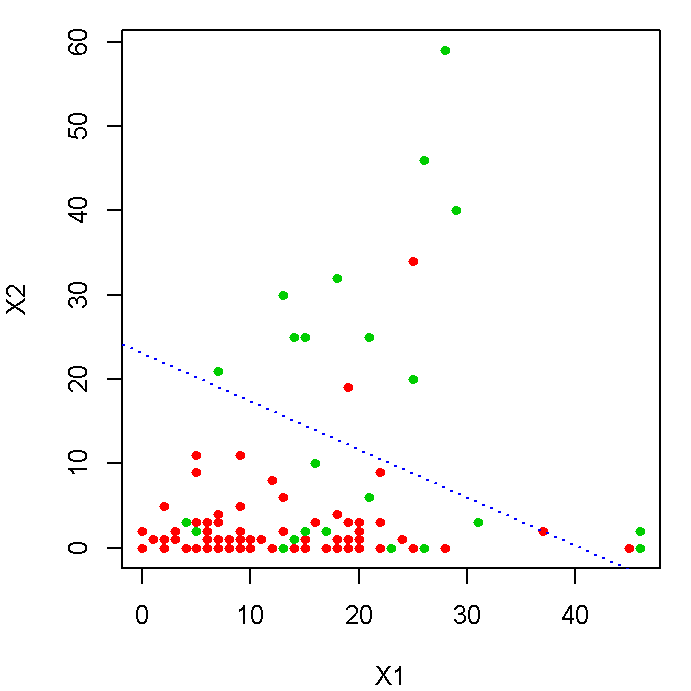

```r
par(cex=0.8, mar=c(4,4,1,1))
plot(D$x1, D$x2, col=2+D$y, pch=20, cex=1.2, xlab="X1", ylab="X2")
abline(-b[1]/b[3], -b[2]/b[3], col="blue", lty=3)
```

Furthermore, we can translate probability, logit and coefficents to intercept & slope …

$$f(x) = b_0 + b_1 x_1 + b_2 x_2 \; \Rightarrow \; x_2 = \frac{f - b_0}{b_2} - \frac{b_1}{b_2}x_1$$

```r
p = seq(0.1,0.9,0.1)
logit = log(p/(1-p))
data.frame(prob = p, logit)
```

```
  prob    logit
1  0.1 -2.19722
2  0.2 -1.38629
3  0.3 -0.84730
4  0.4 -0.40547
5  0.5  0.00000
6  0.6  0.40547
7  0.7  0.84730
8  0.8  1.38629
9  0.9  2.19722
```

then mark the contours of proabilities into the scatter plot

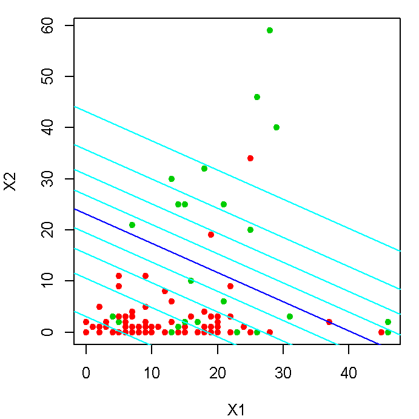

```r
par(cex=0.8, mar=c(4,4,1,1))
plot(D$x1, D$x2, col=2+D$y,
     pch=20, cex=1.3, xlab='X1', ylab='X2')
for(f in logit) {
  abline((f-b[1])/b[3], -b[2]/b[3], col=ifelse(f==0,'blue','cyan')) }
```

🗿 : What do the blue/cyan lines means?

```r
#blue line:線性組合(logit)=0的線，當點落在此線上，代表y=1的機率=0.5。
#cyan lines:藍線以上(右)為線性組合(logit)>0的線，當點落在此線上，代表y=1的機率>0.5，離藍線越遠的線機率越接近1。藍線以下(左)為線性組合(logit)<0的線，當點落在此線上，代表y=1的機率<0.5，離藍線越遠的線機率越接近0。
```

🗿 : Given any point in the figure above, how can you tell its (predicted) probability approximately?

```r
#當點落在藍線以上(右)的空間時，代表y=1的機率>0.5，預測值為y=1。
#當點落在藍線以下(左)的空間時，代表y=1的機率<0.5，預測值為y=0。
```

### 【B】 邏輯式回歸

##### 機率、勝率(Odd)、Logit

- Odd = $p/(1-p)$
- Logit = $log(odd)$ = $log(\frac{p}{1=p})$
- $o = p/(1-p)$ ; $p = o/(1+o)$ ; $logit = log(o)$

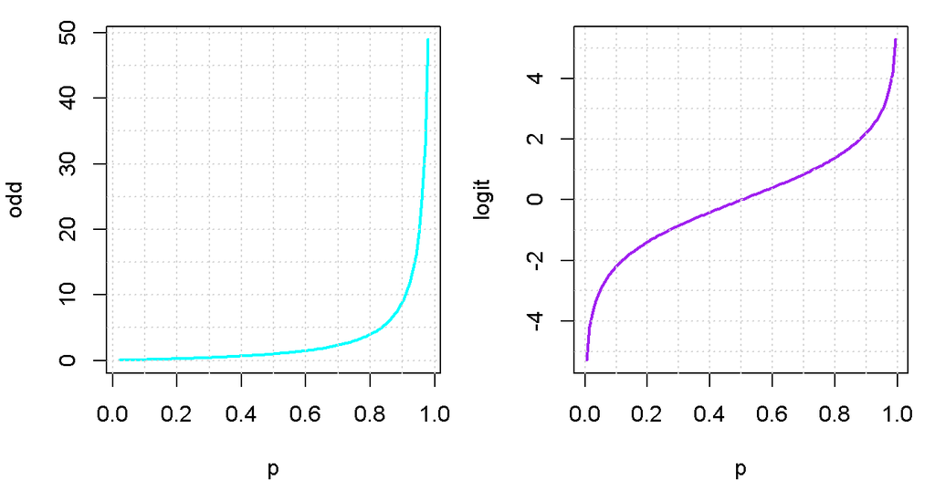

```r
par(cex=0.8, mfcol=c(1,2))
curve(x/(1-x), 0.02, 0.98, col='cyan',lwd=2,
    ylab='odd', xlab='p')
abline(v=seq(0,1,0.1), h=seq(0,50,5), col='lightgray', lty=3)
curve(log(x/(1-x)), 0.005, 0.995, lwd=2, col='purple',
      ylab="logit",xlab='p')
abline(v=seq(0,1,0.1), h=seq(-5,5,1), col='lightgray', lty=3)
```

##### Logistic Function & Logistic Regression

- Linear Model: $y = f(x) = b_0 + b_1x_1 + b_2x_2 + ...$
- General Linear Model(GLM): $y = Link(f(x))$
- Logistic Regression: $logit(y) = log(\frac{p}{1-p}) = f(x) \text{ where } p = prob[y=1]$
- Logistic Function: $Logistic(F_x) = \frac{1}{1+Exp(-F_x)} = \frac{Exp(F_x)}{1+Exp(F_x)}$

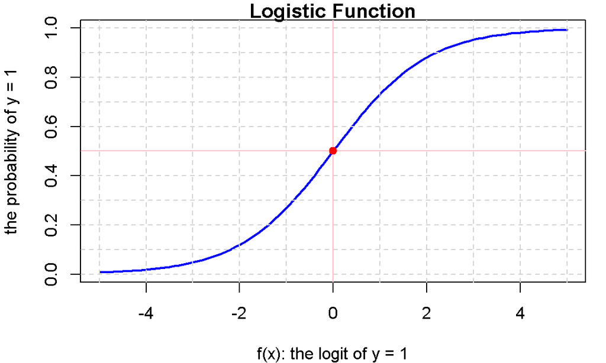

```r
par(cex=0.8, mfrow=c(1,1))
curve(1/(1+exp(-x)), -5, 5, col='blue', lwd=2,main="Logistic Function",
      xlab="f(x): the logit of y = 1", ylab="the probability of y = 1")
abline(v=-5:5, h=seq(0,1,0.1), col='lightgray', lty=2)
abline(v=0,h=0.5,col='pink')
points(0,0.5,pch=20,cex=1.5,col='red')
```

🗿 : What are the definition of `logit` & `logistic function`? What is the relationship between them?

```r
#logit：對數勝算，將勝算（比）取log函數，其值會介於-∞到∞間。可視為x的線性組合。
#logistic function：邏輯函數，將logit（對數勝算）轉換為y=1的機率值，其值會介於0到1之間。用於求出類別變數的目標函數機率。
#當logit線性組合=0時，[y=1]的機率=0.5；logit>0時，[y=1]的機率>0.5；logit<0時，[y=1]的機率<0.5。
```